# Predicción del rating de Las aplicaciones en Google Play Store

## Tuning KNN

- En este caso se va a ampliar el rango de búsqueda de hiperparámetros. Los valores de k estarán optimizados de forma logarítmica y se usa la función exp() para transformar el hiperparámetro y poderlo visualizar en la escala original.
- La distancia se optimiza en escala continua
- Se agregan más tipos de kernel para ver cuál funciona mejor
- Se escalan las variables numéricas
- **Nota:** como se están optimizando “k” en logaritmo, es neceario introducir una función que permita la transformación inversa “trafo”.

```r
# Espacio de búsqueda
large_searchspace <- ParamSet$new(list(
  ParamDbl$new("k", lower = log(2), upper = log(50)),
  ParamDbl$new("distance", lower = 1, upper = 5),
  ParamFct$new("kernel", c("rectangular", "gaussian", "rank", "optimal")),
  ParamLgl$new("scale")
))

# Función para transformación
large_searchspace$trafo <- function(x, param_set){
  x$k = round(exp(x$k))
  x
}
```

- **Tuning Random Search:** en este caso se realizan 36 evaluaciones. Este número es elegido al azar entre todas las opciones posibles del espacio de búsqueda anterior.

```r
# Tipo de tuning
tuner_random <- tnr("random_search", batch_size = 36)

instance_random <- TuningInstanceSingleCrit$new(
  task = task,
  learner = knn,
  resampling = cv10_instance,
  measure = msr("classif.fbeta"),
  search_space = large_searchspace,
  terminator = trm("evals", n_evals = 36)
)
```

- **Entrenamiento de modelos:** aproximadamente 15 minutos de ejecución.

```r
tuner_random$optimize(instance_random)
```

- **Resultados del ajuste:**

```r
instance_random$archive$data()
```

| k | distance | kernel | scale | classif.fbeta | uhash | x_domain | timestamp | batch_nr |
| --- | --- | --- | --- | --- | --- | --- | --- | --- |
| 1.9711762 | 2.117790 | optimal | TRUE | 0.29506228 | 395ae387-3e38-4840-8488-48deec108442 |  | 2020-10-18 18:00:11 | 1 |
| 2.9725591 | 4.577639 | rank | FALSE | 0.30713530 | a3914c66-614b-4088-93d6-54504a7255e9 |  | 2020-10-18 18:00:11 | 1 |
| 3.3911673 | 3.018436 | gaussian | TRUE | 0.15102691 | c02f59f3-7770-4baa-b4c3-621d4929c0fb |  | 2020-10-18 18:00:11 | 1 |
| 2.1942054 | 4.935785 | rectangular | TRUE | 0.20099368 | 804ecb32-b623-4364-b7e2-4aa8892a56d9 |  | 2020-10-18 18:00:11 | 1 |
| 3.4502103 | 3.108596 | gaussian | FALSE | 0.26505292 | 63be39ad-fb6d-4053-9d6f-06658c726048 |  | 2020-10-18 18:00:11 | 1 |
| 3.0896102 | 4.425713 | optimal | FALSE | 0.32506859 | 1a0c80a5-a530-48ed-80bc-2f16c14cd970 |  | 2020-10-18 18:00:11 | 1 |
| 3.8805099 | 3.418188 | gaussian | TRUE | 0.10200544 | 95511689-ab2e-4a33-8bda-8e3001f6a042 |  | 2020-10-18 18:00:11 | 1 |
| 1.5510311 | 4.087714 | gaussian | TRUE | 0.26175401 | 5d33c24b-dc93-4d45-b410-d94001008864 |  | 2020-10-18 18:00:11 | 1 |
| 3.2043566 | 2.058453 | rectangular | TRUE | 0.11078234 | 4446aa57-9aab-4bf6-8b72-9b3f4bb5a675 |  | 2020-10-18 18:00:11 | 1 |
| 3.8352655 | 1.775945 | rank | TRUE | 0.07837054 | f5660d29-4637-4c86-925d-8de8e596fd12 |  | 2020-10-18 18:00:11 | 1 |

[output cut: 26 more lines]

- Como los valores de “k” están dados en logaritmos pero internamente se pasó la función para transformarlos, están contenidos en la variable “x_domain”.

```r
instance_random$archive$data(unnest = "x_domain")
```

| k | distance | kernel | scale | classif.fbeta | uhash | timestamp | batch_nr | x_domain_k | x_domain_distance | x_domain_kernel | x_domain_scale |
| --- | --- | --- | --- | --- | --- | --- | --- | --- | --- | --- | --- |
| 1.9711762 | 2.117790 | optimal | TRUE | 0.29506228 | 395ae387-3e38-4840-8488-48deec108442 | 2020-10-18 18:00:11 | 1 | 7 | 2.117790 | optimal | TRUE |
| 2.9725591 | 4.577639 | rank | FALSE | 0.30713530 | a3914c66-614b-4088-93d6-54504a7255e9 | 2020-10-18 18:00:11 | 1 | 20 | 4.577639 | rank | FALSE |
| 3.3911673 | 3.018436 | gaussian | TRUE | 0.15102691 | c02f59f3-7770-4baa-b4c3-621d4929c0fb | 2020-10-18 18:00:11 | 1 | 30 | 3.018436 | gaussian | TRUE |
| 2.1942054 | 4.935785 | rectangular | TRUE | 0.20099368 | 804ecb32-b623-4364-b7e2-4aa8892a56d9 | 2020-10-18 18:00:11 | 1 | 9 | 4.935785 | rectangular | TRUE |
| 3.4502103 | 3.108596 | gaussian | FALSE | 0.26505292 | 63be39ad-fb6d-4053-9d6f-06658c726048 | 2020-10-18 18:00:11 | 1 | 32 | 3.108596 | gaussian | FALSE |
| 3.0896102 | 4.425713 | optimal | FALSE | 0.32506859 | 1a0c80a5-a530-48ed-80bc-2f16c14cd970 | 2020-10-18 18:00:11 | 1 | 22 | 4.425713 | optimal | FALSE |
| 3.8805099 | 3.418188 | gaussian | TRUE | 0.10200544 | 95511689-ab2e-4a33-8bda-8e3001f6a042 | 2020-10-18 18:00:11 | 1 | 48 | 3.418188 | gaussian | TRUE |
| 1.5510311 | 4.087714 | gaussian | TRUE | 0.26175401 | 5d33c24b-dc93-4d45-b410-d94001008864 | 2020-10-18 18:00:11 | 1 | 5 | 4.087714 | gaussian | TRUE |
| 3.2043566 | 2.058453 | rectangular | TRUE | 0.11078234 | 4446aa57-9aab-4bf6-8b72-9b3f4bb5a675 | 2020-10-18 18:00:11 | 1 | 25 | 2.058453 | rectangular | TRUE |
| 3.8352655 | 1.775945 | rank | TRUE | 0.07837054 | f5660d29-4637-4c86-925d-8de8e596fd12 | 2020-10-18 18:00:11 | 1 | 46 | 1.775945 | rank | TRUE |

[output cut: 26 more lines]

- ¿Resultó útil escalar las variables para este algoritmo? el gráfico permite intuir que no es provechoso en términos de rendimiento predictivo esclar las variables numéricas.

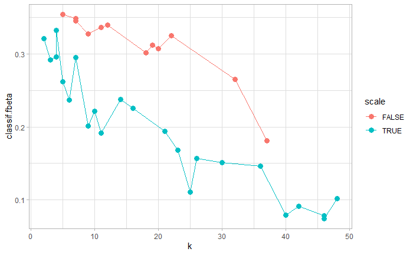

```r
instance_random$archive$data(unnest = "x_domain") %>%
  ggplot(aes(x = x_domain_k, y = classif.fbeta, color = scale)) +
  geom_point(size = 3) +
  geom_line() +
  labs(x = "k")
```

- ¿Cuál kernel proporciona mejores resultados? el kernel rectangular funciona bien con “k” bajo. Los kernel rank y gaussian proporcionan buenos resultados con “k” entre 10 y 20.

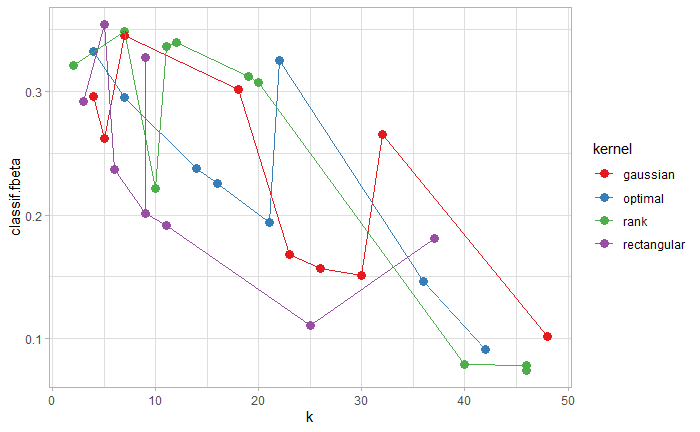

```r
instance_random$archive$data(unnest = "x_domain") %>%
  ggplot(aes(x = x_domain_k, y = classif.fbeta, color = kernel)) +
  geom_point(size = 3) +
  geom_line() +
  labs(x = "k") +
  scale_color_brewer(palette = "Set1")
```

## Mejores modelos

- **Modelo KNN basal (grid search):**
  - k = 3
  - distance = 2

```r
instance_grid$result
```

| k | distance | learner_param_vals | x_domain | classif.fbeta |
| --- | --- | --- | --- | --- |
| 3 | 2 |  |  | 0.3000328 |

- **Modelo KNN Tuning (random search):**
  - k = 5
  - kernel = rectangular
  - scale = FALSE
  - distance = 1.164304

| k | distance | kernel | scale | classif.fbeta | uhash | timestamp | batch_nr | x_domain_k | x_domain_distance | x_domain_kernel | x_domain_scale |
| --- | --- | --- | --- | --- | --- | --- | --- | --- | --- | --- | --- |
| 1.609475 | 1.164304 | rectangular | FALSE | 0.3541462 | 03ac2d90-8f20-4a6c-9725-4bffc48ed19b | 2020-10-18 18:00:11 | 1 | 5 | 1.164304 | rectangular | FALSE |

## Modelo final

```r
#Tarea
task_final <- TaskClassif$new(id = "rating_app2",
                              backend = new_train1,
                              target = "Rating")


# Algoritmo con hiperparámetros sintonizados
knn_final <- lrn("classif.kknn", predict_type = "prob")
knn_final$param_set$values$kernel <- "rectangular"
knn_final$param_set$values$distance <- 1.164304
knn_final$param_set$values$k <- 5

# Entrenamiento
knn_final$train(task_final)
```

## Predicciones

```r
#Predicciones
predict_prob <- knn_final$predict_newdata(newdata = new_test1)

# Submission
sampleSub %>%
  select(-rating) %>%
  mutate(rating = predict_prob$data$response) ->
  sub_01_knn
head(sub_01_knn)
```

| id | rating |
| --- | --- |
| 5788 | 1 |
| 5789 | 1 |
| 5790 | 1 |
| 5791 | 1 |
| 5792 | 1 |
| 5793 | 1 |

- **Exportando predicciones:**

```r
write_csv(sub_01_knn, file = "../submission/knn_01.csv")
```